# Course Project

Joshua Goldberg

December, 06 2018

# Data

The data of the project contains 5 factors:

- `Sex` (2 levels)
- `Race` (4 levels)
- `Age` (5 levels)
- `Education` (3 levels)
- `State` (51 levels)

The total number of combinations of levels is 6120.

Look at the data.

Check the variables notation:

```r
dat <- read.csv("assignments-Bayesian Methods-Course Project 32014-MScA_32014_BayesianMethods_CourseProjectData.csv")
head(dat)
```

|  | sex | race | age | education | state | y |
| --- | --- | --- | --- | --- | --- | --- |
| 1 | 1.Male | 1.White | 18-24 | 1.NoCollege | GA | 0 |
| 2 | 1.Male | 1.White | 25-34 | 1.NoCollege | AZ | 0 |
| 3 | 1.Male | 1.White | 25-34 | 2.SomeCollege | SD | 0 |
| 4 | 1.Male | 1.White | 18-24 | 3.CollegeOrMore | SC | 0 |
| 5 | 1.Male | 1.White | 18-24 | 3.CollegeOrMore | SC | 0 |
| 6 | 1.Male | 1.White | 18-24 | 3.CollegeOrMore | SC | 0 |

```r
unique(dat$sex)
```

```
## [1] 1.Male   2.Female
## Levels: 1.Male 2.Female
```

```r
unique(dat$race)
```

```
## [1] 1.White    2.Black    3.Hispanic 4.Other
## Levels: 1.White 2.Black 3.Hispanic 4.Other
```

```r
unique(dat$age)
```

```
## [1] 18-24 25-34 35-44 45-54 55+
## Levels: 18-24 25-34 35-44 45-54 55+
```

```r
unique(dat$education)
```

```
## [1] 1.NoCollege     2.SomeCollege   3.CollegeOrMore
## Levels: 1.NoCollege 2.SomeCollege 3.CollegeOrMore
```

```r
unique(dat$state)
```

```
##  [1] GA AZ SD SC AL VA KS TN IA ME AR WA CT OH PA MA NH MD WI NE MS CA NY
## [24] DE MN MI ND ID HI IN VT FL OK UT NM KY LA WY DC RI IL OR NJ MT MO CO
## [47] NV WV AK NC TX
## 51 Levels: AK AL AR AZ CA CO CT DC DE FL GA HI IA ID IL IN KS KY LA ... WY
```

# Model

After running MCMC with the these data and the model obtain a Markov chain posterior sample for 870 parameters including 2-way interactions. Each Markov chain of the stan object `obama_fit` has length 36000.

Explore the fitted model object. It is not necessary to reproduce the results shown below, but if you see significant differences, please, report.

Launch `shinystan()` to explore the chains for convergence.

```r
load("assignments-Bayesian Methods-Course Project 32014-Run05272016-fit_ext_20160527_103144.Rdata")
```

```r
launch_shinystan(obama_fit)
```

# Analysis

## Extract chains for further analysis

```r
MCMC <- rstan::extract(obama_fit)
MCMC %>% names()
```

```
##  [1] "b_0"                 "b_sex"               "b_race"
##  [4] "b_age"               "b_education"         "b_state"
##  [7] "b_sex_race"          "b_sex_age"           "b_sex_education"
## [10] "b_sex_state"         "b_race_age"          "b_race_education"
## [13] "b_race_state"        "b_age_education"     "b_age_state"
## [16] "b_education_state"   "var_0"               "var_sex"
## [19] "var_race"            "var_age"             "var_education"
## [22] "var_state"           "var_sex_race"        "var_sex_age"
## [25] "var_sex_education"   "var_sex_state"       "var_race_age"
## [28] "var_race_education"  "var_race_state"      "var_age_education"
## [31] "var_age_state"       "var_education_state" "nu"
## [34] "sigma"               "lp__"
```

## Significant parameters

Explore `sum.obama_fit` - summary of `obama_fit`.

Find parameters which are significantly different from zero: zero does not belong to 95% HDI. Show selected parameters.

```r
sum.obama_fit <- summary(obama_fit)$summary %>% data.frame()

significant_co <- function(stan_fit) {
  summ <- summary(stan_fit)$summary %>% data.frame()
  !(summ$X2.5. < 0 & summ$X97.5. > 0)
}
```

```r
sum.obama_fit[significant_co(obama_fit), c(4, 8)]
```

|  | X2.5. | X97.5. |
| --- | --- | --- |
| b_0 | 4.116903e-01 | 5.832719e-01 |
| b_sex[1] | -1.905134e-01 | -5.765717e-02 |
| b_sex[2] | 5.765717e-02 | 1.905134e-01 |
| b_race[1] | -1.359407e+00 | -1.178978e+00 |
| b_race[2] | 2.111867e+00 | 2.506630e+00 |
| b_race[3] | -6.431486e-01 | -3.649229e-01 |
| b_race[4] | -6.578031e-01 | -4.089638e-01 |
| b_age[1] | 1.098589e-01 | 3.798599e-01 |
| b_age[2] | 6.147626e-03 | 2.474967e-01 |
| b_age[5] | -3.951658e-01 | -1.537930e-01 |

[output cut: 63 more lines]

The model parameters are re-centered to satisfy additional constraint $(\sum_i \beta_i = 0)$, so, for example slopes of gender predictor are:

```r
sum.obama_fit[2:3, 1]
```

```
## [1] -0.1214598  0.1214598
```

```r
sum(sum.obama_fit[2:3, 1])
```

```
## [1] 1.387779e-17
```

As a result estimated intercept is close to 0.5:

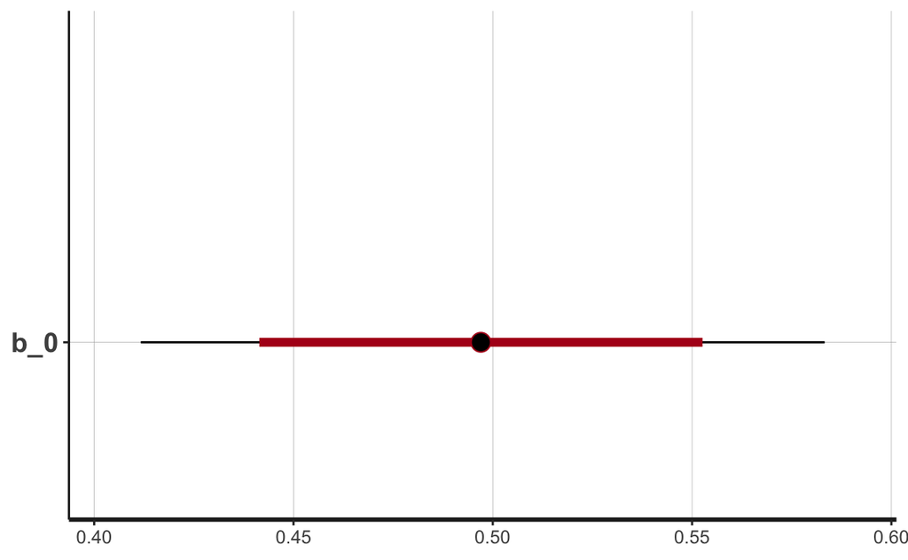

```r
plot(obama_fit, pars = c("b_0"))
```

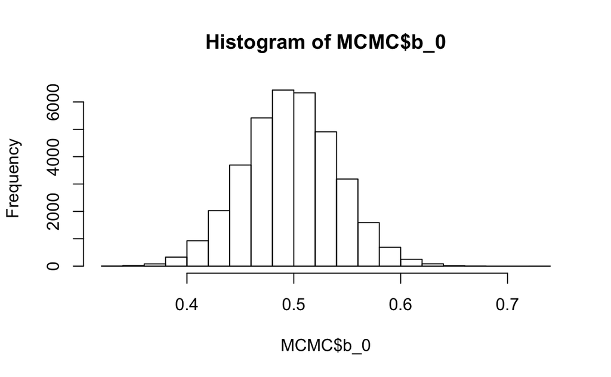

```r
hist(MCMC$b_0)
```

```r
mean(MCMC$b_0)
```

```
## [1] 0.4971177
```

## Reviewing main effects

Plot HDIs for the 5 main parameters. For example:

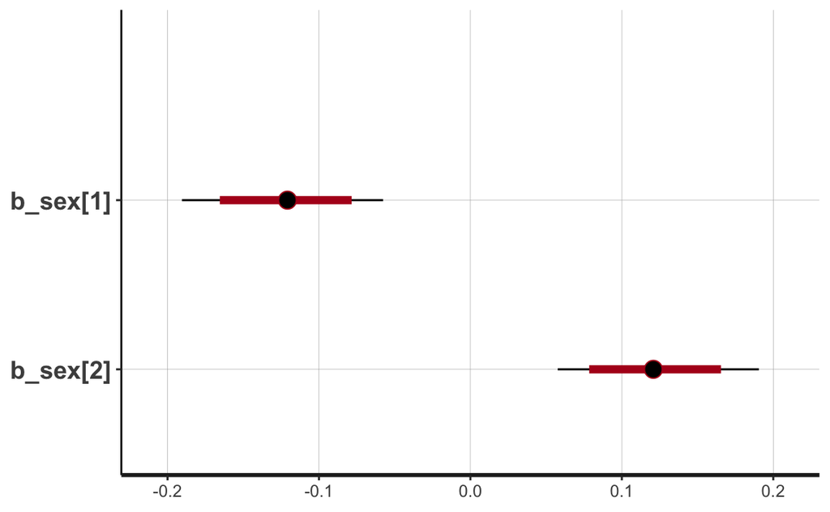

```r
plot(obama_fit, pars = c("b_sex"))
```

## Interactions

Interpretation of interactions. Look, for example, at interaction between sex and race.

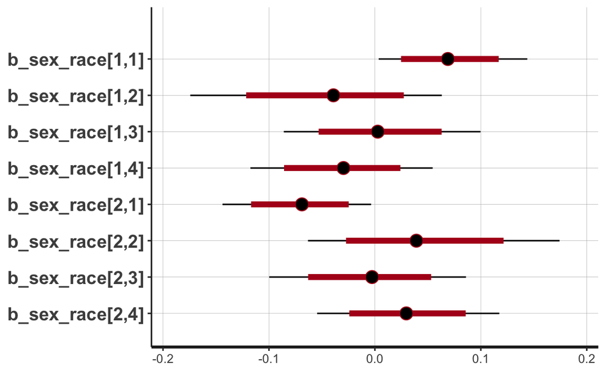

```r
plot(obama_fit, pars = c("b_sex_race"))
```

```r
sum.obama_fit[67:74, c(1, 4, 8)]
```

|  | mean | X2.5. | X97.5. |
| --- | --- | --- | --- |
| b_sex_race[1,1] | 0.07000647 | 0.003575282 | 0.143861731 |
| b_sex_race[1,2] | -0.04379414 | -0.174292010 | 0.063163381 |
| b_sex_race[1,3] | 0.00392710 | -0.085982318 | 0.099682650 |
| b_sex_race[1,4] | -0.03013943 | -0.117475813 | 0.054531941 |
| b_sex_race[2,1] | -0.07000647 | -0.143861731 | -0.003575282 |
| b_sex_race[2,2] | 0.04379414 | -0.063163381 | 0.174292010 |
| b_sex_race[2,3] | -0.00392710 | -0.099682650 | 0.085982318 |
| b_sex_race[2,4] | 0.03013943 | -0.054531941 | 0.117475813 |

```r
sum.obama_fit[c(67, 70), c(1, 4, 8)]
```

|  | mean | X2.5. | X97.5. |
| --- | --- | --- | --- |
| b_sex_race[1,1] | 0.07000647 | 0.003575282 | 0.14386173 |
| b_sex_race[1,4] | -0.03013943 | -0.117475813 | 0.05453194 |

Recall that `sex[1]` is “Male” and `sex[2]` is “Female”, and `race[1]` means “White” and `race[4]` means “Other”. Main parameters and their corresponding interactions are then:

```r
sum.obama_fit[c(1:4, 7, 67, 70), c(1, 4, 8)]
```

|  | mean | X2.5. | X97.5. |
| --- | --- | --- | --- |
| b_0 | 0.49711769 | 0.411690314 | 0.58327189 |
| b_sex[1] | -0.12145982 | -0.190513365 | -0.05765717 |
| b_sex[2] | 0.12145982 | 0.057657169 | 0.19051337 |
| b_race[1] | -1.26909677 | -1.359407127 | -1.17897800 |
| b_race[4] | -0.53312966 | -0.657803084 | -0.40896376 |
| b_sex_race[1,1] | 0.07000647 | 0.003575282 | 0.14386173 |
| b_sex_race[1,4] | -0.03013943 | -0.117475813 | 0.05453194 |

Interpret these parameters as influence over odds ratio.

```r
(odds <- exp(sum.obama_fit[c(1:4, 7, 67, 70), c(1, 4, 8)][, 1]))
```

```
## [1] 1.6439760 0.8856266 1.1291440 0.2810854 0.5867657 1.0725151 0.9703102
```

The baseline odds ratio is 1.643976, meaning that the ratio of people approving Obama as candidate to disapproving him is 1.643976.

```r
prod(odds[1:2])
```

```
## [1] 1.455949
```

And among females it is higher:

```r
prod(odds[c(1, 3)])
```

```
## [1] 1.856286
```

Approval odds for 1.Whiteand 4.Other are:

```r
odds[c(1, 4)]
```

```
## [1] 1.6439760 0.2810854
```

```r
prod(odds[c(1, 4)])
```

```
## [1] 0.4620976
```

```r
odds[c(1, 5)]
```

```
## [1] 1.6439760 0.5867657
```

```r
prod(odds[c(1, 5)])
```

```
## [1] 0.9646288
```

Approval odds among white males $(sex=1,race=1)$ is:

```r
odds[c(1, 2, 4, 6)]
```

```
## [1] 1.6439760 0.8856266 0.2810854 1.0725151
```

```r
prod(odds[c(1, 2, 4, 6)])
```

```
## [1] 0.4389225
```

Which is better than in the case when interaction is not included:

```r
odds[c(1, 2, 4)]
```

```
## [1] 1.6439760 0.8856266 0.2810854
```

```r
prod(odds[c(1, 2, 4)])
```

```
## [1] 0.409246
```

```r
odds[c(1, 3, 4)]
```

```
## [1] 1.6439760 1.1291440 0.2810854
```

```r
prod(odds[c(1, 3, 4)])
```

```
## [1] 0.5217748
```

# Project questions

1. Find the most supportive groups corresponding to each of the main effects for Barack Obama in 2012.
2. Find the least supportive group corresponding to each of the main effects.
3. Compare odds of approval by males grouped by race and education. Which of such subgroups shows the highest and the lowest support for the candidate.
4. Answer the same question, but for females

For convenience create groups of necessary parameters and give them intuitive column names.

```r
ch_b0 <- MCMC$b_0
ch_b_sex <- MCMC$b_sex
colnames(ch_b_sex) <- levels(dat$sex)

ch_b_race <- MCMC$b_race
colnames(ch_b_race) <- levels(dat$race)

ch_b_age <- MCMC$b_age
colnames(ch_b_age) <- levels(dat$age)

ch_b_education <- MCMC$b_education
colnames(ch_b_education) <- levels(dat$education)

ch_b_state <- MCMC$b_state
colnames(ch_b_state) <- levels(dat$state)

ch_b_sex_race <- MCMC$b_sex_race
dimnames(ch_b_sex_race)[[2]] <- levels(dat$sex)
dimnames(ch_b_sex_race)[[3]] <- levels(dat$race)

ch_b_sex_education <- MCMC$b_sex_education
dimnames(ch_b_sex_education)[[2]] <- levels(dat$sex)
dimnames(ch_b_sex_education)[[3]] <- levels(dat$education)

ch_b_race_education <- MCMC$b_race_education
dimnames(ch_b_race_education)[[2]] <- levels(dat$race)
dimnames(ch_b_race_education)[[3]] <- levels(dat$education)
```

## Main effects

### Grouped by gender

Calculate mean, lower and upper HDI levels for odds of approval by gender. Calculate mean values and HDI limits for log-odds and then take exponents of them.

```r
calculate_odds <- function(var) {
  rbind(mean = apply(var, 2, function(x) exp(mean(x + ch_b0))), apply(var, 2, function(x) exp(hdi(x + ch_b0))))
}
```

### Grouped by sex

```r
(ch_b_sex_odds <- calculate_odds(ch_b_sex))
```

```
##         1.Male 2.Female
## mean  1.455949 1.856286
## lower 1.294588 1.679686
## upper 1.630791 2.050351
```

```r
which.max(ch_b_sex_odds[1, ])
```

```
## 2.Female
##        2
```

```r
which.min(ch_b_sex_odds[1, ])
```

```
## 1.Male
##      1
```

Define convenience function for plotting:

```r
add_spaces <- function(string) {
  str_remove_all(string, "\\d\\.") %>%
      str_replace_all("([[:upper:]])", " \\1") %>%
      str_trim("both")
}

plot_odds <- function(odds_matrix) {
  data <- odds_matrix[1,] %>%
    data.frame(odds = .) %>%
    rownames_to_column(var = "var")

  edu_check <- unique(data$var %>% str_detect("College"))

  if (edu_check) {
    edu_names <- add_spaces(data$var)
  }

  data <- data %>%
    mutate(var = str_remove_all(var, "\\d\\.")) %>%
    mutate(var = if(edu_check) edu_names else var,
           var = factor(var, levels = var[order(odds, decreasing = TRUE)], ordered = TRUE))
  age_check <- unique(data$var %>% str_detect("\\d"))
  data %>%
    ggplot(aes(var, odds), odds) +
    geom_col(fill = "skyblue") +
    labs(
      title = glue::glue("{levels(data$var)[1]}{ifelse(age_check, ' Age Group', '')} Shows Highest Support for Obama"),
      x = "Group",
      y = "Odds"
    )
}
```

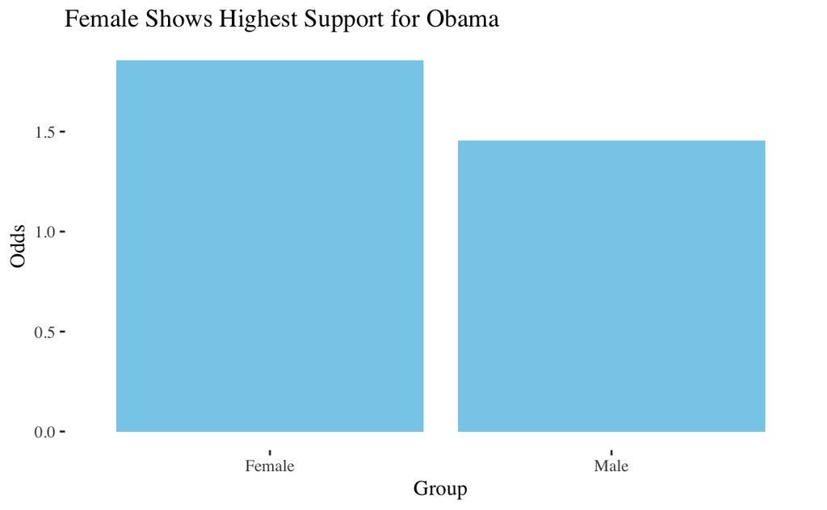

```r
plot_odds(ch_b_sex_odds)
```

### Grouped by race

```r
(ch_b_race_odds <- calculate_odds(ch_b_race))
```

```
##         1.White  2.Black 3.Hispanic   4.Other
## mean  0.4620976 16.50647  0.9927362 0.9646288
## lower 0.4430622 12.84272  0.8443836 0.8432129
## upper 0.4824002 21.37102  1.1649948 1.1014265
```

```r
which.max(ch_b_race_odds[1, ])
```

```
## 2.Black
##       2
```

```r
which.min(ch_b_race_odds[1, ])
```

```
## 1.White
##       1
```

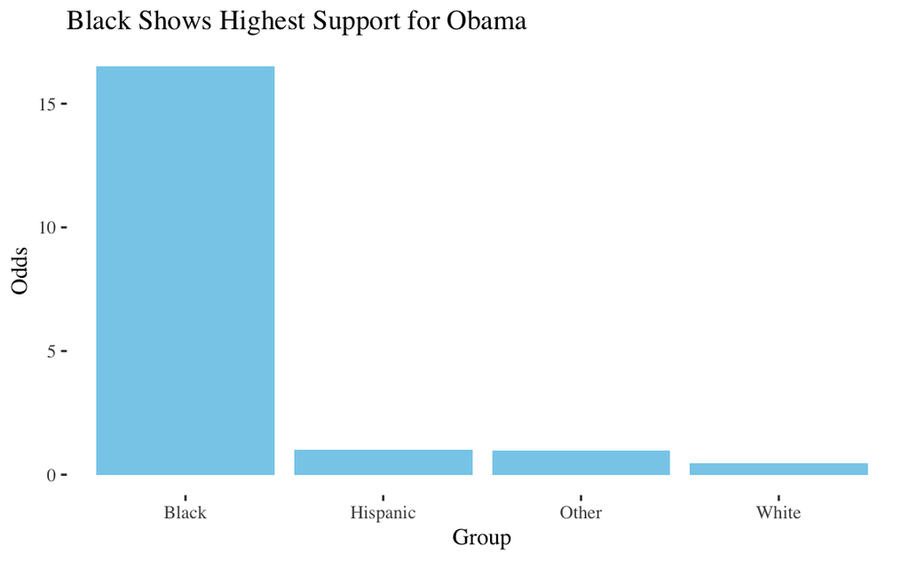

```r
plot_odds(ch_b_race_odds)
```

### Grouped by age

```r
(ch_b_age_odds <- calculate_odds(ch_b_age))
```

```
##          18-24    25-34    35-44    45-54      55+
## mean  2.103702 1.866141 1.605320 1.523512 1.250665
## lower 1.786283 1.616481 1.366515 1.308444 1.081427
## upper 2.474256 2.164906 1.871676 1.775774 1.437299
```

```r
which.max(ch_b_age_odds[1, ])
```

```
## 18-24
##     1
```

```r
which.min(ch_b_age_odds[1, ])
```

```
## 55+
##   5
```

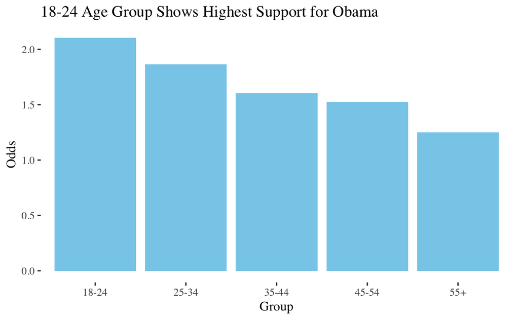

```r
plot_odds(ch_b_age_odds)
```

### Grouped by education

```r
(ch_b_education_odds <- calculate_odds(ch_b_education))
```

```
##       1.NoCollege 2.SomeCollege 3.CollegeOrMore
## mean     1.515840      1.673248        1.751752
## lower    1.333525      1.504955        1.546969
## upper    1.732132      1.871543        1.995538
```

```r
which.max(ch_b_education_odds[1, ])
```

```
## 3.CollegeOrMore
##               3
```

```r
which.min(ch_b_education_odds[1, ])
```

```
## 1.NoCollege
##           1
```

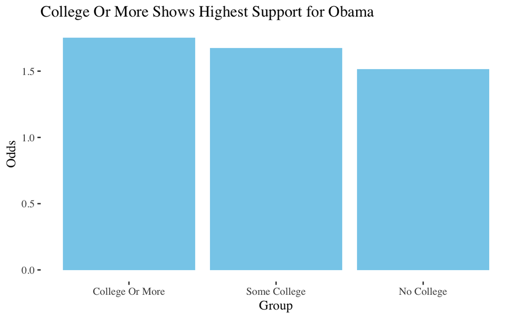

```r
plot_odds(ch_b_education_odds)
```

### Grouped by state

```r
(ch_b_state_odds <- calculate_odds(ch_b_state))
```

```
##              AK        AL        AR       AZ       CA       CO       CT
## mean  1.3476856 0.9696427 1.1393769 1.690446 1.985228 1.874901 2.077820
## lower 0.8827718 0.6552689 0.7871296 1.194617 1.484320 1.325678 1.459179
## upper 2.0098714 1.4158702 1.6215941 2.352537 2.638478 2.652787 3.003641
##             DC       DE       FL        GA       HI       IA        ID
## mean  3.604544 2.216578 1.725519 1.2345273 3.129431 2.238279 1.3083928
## lower 2.248595 1.473026 1.224880 0.9215636 2.197365 1.516694 0.8760142
## upper 5.771946 3.329536 2.365356 1.6550056 4.438253 3.290229 1.9734203
##             IL        IN        KS       KY        LA       MA       MD
## mean  2.628237 1.0519490 1.0881749 1.619371 0.9720502 2.474350 1.884324
## lower 1.900043 0.7188661 0.7387039 1.095936 0.6975811 1.729469 1.377507
## upper 3.733680 1.5067773 1.5541253 2.358757 1.3587647 3.572645 2.570738
##             ME       MI       MN        MO        MS        MT        NC
## mean  1.889644 1.978596 2.643456 1.4260513 0.9628397 1.1186730 1.3487614
## lower 1.238782 1.358984 1.773180 0.9808641 0.6519408 0.7306527 0.9542182
## upper 2.893011 2.850413 3.910435 2.0746917 1.4208505 1.6911993 1.8963021
##             ND       NE        NH       NJ       NM        NV       NY
## mean  1.567775 1.751783 1.4694228 2.291579 1.604123 1.3754591 2.165378
## lower 1.011873 1.178856 0.9331125 1.669673 1.144317 0.9754387 1.548402
## upper 2.428760 2.603631 2.2804704 3.239776 2.254516 1.9150176 3.005885
##             OH       OK       OR       PA       RI       SC       SD
## mean  2.181995 1.136575 1.554238 2.120849 2.194671 1.233403 1.660243
## lower 1.472890 0.805980 1.080299 1.446736 1.432160 0.974229 1.065935
## upper 3.180823 1.603605 2.262743 3.112789 3.378892 1.571722 2.547570
##              TN        TX        UT       VA       VT       WA       WI
## mean  1.0479435 1.1781476 1.2767905 1.743564 3.071641 2.487922 1.809932
## lower 0.7280519 0.8737884 0.8734067 1.284176 1.821589 1.767373 1.216294
## upper 1.4820015 1.5814508 1.8921464 2.392000 5.118829 3.582052 2.645143
##              WV        WY
## mean  1.0838929 1.1162077
## lower 0.7094964 0.7155686
## upper 1.6773978 1.6997658
```

```r
which.max(ch_b_state_odds[1, ])
```

```
## DC
##  8
```

```r
which.min(ch_b_state_odds[1, ])
```

```
## MS
## 26
```

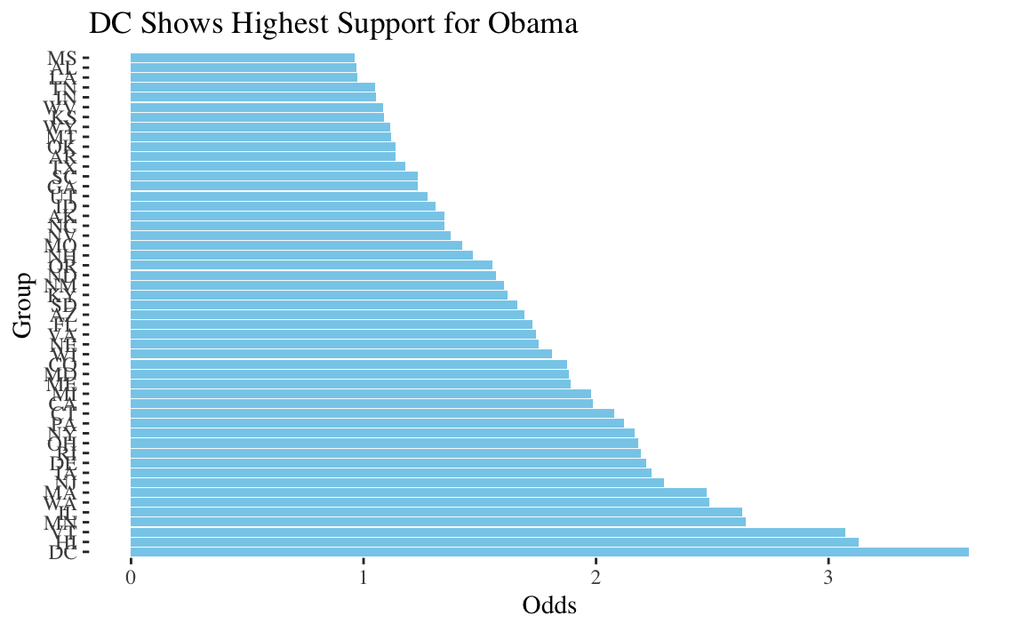

```r
plot_odds(ch_b_state_odds) +
  coord_flip()
```

## Interactions

### Males

Calculate mean values and log-odds limits for each race-education combination. Then take exponents of them.

Calculate mean and HDI of each column of the cube.

Compare groups.

```r
run <- 12
ch_bo_cube <- purrr::rerun(run, cbind(ch_b0)) %>%
  bind_cols() %>%
  set_names(rep("ch_b0", run)) %>%
  as.matrix()
dim(ch_bo_cube) <- dim(ch_b_race_education)

ch_race_cube <- cbind(ch_b_race, ch_b_race, ch_b_race)
dim(ch_race_cube) <- dim(ch_b_race_education)
dimnames(ch_race_cube) <- dimnames(ch_b_race_education)

ch_b_education_cube <- cbind(ch_b_education, ch_b_education, ch_b_education, ch_b_education)

dim(ch_b_education_cube) <- dim(ch_b_race_education)[c(1, 3, 2)]

ch_b_education_cube <- aperm(ch_b_education_cube, c(1, 3, 2))

dimnames(ch_b_education_cube) <- dimnames(ch_b_race_education)

total_male <- ch_bo_cube + ch_b_sex[, "1.Male"] + ch_race_cube + ch_b_education_cube + ch_b_race_education
total_female <- ch_bo_cube + ch_b_sex[, "2.Female"] + ch_race_cube + ch_b_education_cube + ch_b_race_education
```

```r
(orM_mean <- apply(total_male, c(2, 3), function(x) mean(x)))
```

```
##
##              1.NoCollege 2.SomeCollege 3.CollegeOrMore
##   1.White     -1.0621128   -0.94585601     -0.67234793
##   2.Black      2.6136840    2.77211123      2.66108165
##   3.Hispanic  -0.1194900   -0.17415100     -0.09260948
##   4.Other     -0.2540419   -0.07887639     -0.13949712
```

```r
(orM_HDI <- apply(total_male, c(2, 3), function(x) hdi(x)))
```

```
## , ,  = 1.NoCollege
##
##
##           1.White  2.Black 3.Hispanic     4.Other
##   lower -1.165419 2.282065 -0.3831312 -0.50168211
##   upper -0.957524 2.971747  0.1451652 -0.01521954
##
## , ,  = 2.SomeCollege
##
##
##           1.White  2.Black  3.Hispanic    4.Other
##   lower -1.040187 2.451264 -0.39000004 -0.2794081
##   upper -0.857496 3.090033  0.04273974  0.1241406
##
## , ,  = 3.CollegeOrMore
##
##
##            1.White  2.Black 3.Hispanic     4.Other
##   lower -0.7677193 2.307093 -0.3423469 -0.33622700
##   upper -0.5767772 3.025455  0.1529047  0.05152855
```

```r
exp(orM_mean)
```

```
##
##              1.NoCollege 2.SomeCollege 3.CollegeOrMore
##   1.White      0.3457246     0.3883470       0.5105085
##   2.Black     13.6492428    15.9923620      14.3117611
##   3.Hispanic   0.8873729     0.8401700       0.9115494
##   4.Other      0.7756593     0.9241542       0.8697955
```

```r
exp(orM_HDI)
```

```
## , ,  = 1.NoCollege
##
##
##           1.White   2.Black 3.Hispanic   4.Other
##   lower 0.3117919  9.796894  0.6817234 0.6055113
##   upper 0.3838421 19.526008  1.1562306 0.9848957
##
## , ,  = 2.SomeCollege
##
##
##           1.White  2.Black 3.Hispanic   4.Other
##   lower 0.3533885 11.60301  0.6770568 0.7562313
##   upper 0.4242230 21.97780  1.0436662 1.1321750
##
## , ,  = 3.CollegeOrMore
##
##
##           1.White  2.Black 3.Hispanic   4.Other
##   lower 0.4640703 10.04518  0.7101018 0.7144609
##   upper 0.5617057 20.60337  1.1652140 1.0528793
```

Define convenience functions for plotting:

```r
data_frame_interaction <- function(interaction_matrix) {
  interaction_matrix %>%
  data.frame() %>%
  rownames_to_column(var = "race") %>%
  gather(key = "education", value = "odds", -1) %>%
  mutate(race = str_remove_all(race, "\\d\\."),
         education = str_remove_all(education, "^X\\d\\.") %>%
           add_spaces())
}

plot_interaction_odds <- function(interaction_matrix, title = NULL, subtitle = NULL) {
  data_frame_interaction(interaction_matrix) %>%
    group_by(race) %>%
    arrange(desc(odds), .by_group = TRUE) %>%
    add_count(race) %>%
    mutate(ordered_groups = factor(rep(1:n[[1]]), ordered = TRUE)) %>%
    ungroup() %>%
    ggplot(aes(race, odds, fill = education, group = ordered_groups)) +
    geom_col(position = "dodge") +
    geom_label(
      aes(label = round(odds, 2), group = ordered_groups),
      fill = "white",
      position = position_dodge(width = .9),
      size = 2
    ) +
    scale_fill_viridis_d(name = NULL) +
    labs(title = title,
         subtitle = subtitle,
         caption = "Note: Values are odds of supporting Obama.",
         x = "Race",
         y = "Odds") +
    theme(
      axis.title.y = element_blank(),
      axis.text.y = element_blank(),
      axis.line.y = element_blank(),
      axis.ticks.y = element_blank(),
      axis.ticks.x = element_blank(),
      legend.position = "top"
    )
}
```

[figure not shown]

```r
plot_interaction_odds(orM_mean, title = "Black Males with Some College Show Highest Support for Obama",
                      subtitle = "White Males with No College Show Least Support")
```

### Females

Calculate mean and HDI of each column of the cube.

Compare groups.

```r
(orF_mean <- apply(total_female, c(2, 3), function(x) mean(x)))
```

```
##
##              1.NoCollege 2.SomeCollege 3.CollegeOrMore
##   1.White    -0.81919311   -0.70293637      -0.4294283
##   2.Black     2.85660369    3.01503088       2.9040013
##   3.Hispanic  0.12342969    0.06876865       0.1503102
##   4.Other    -0.01112221    0.16404326       0.1034225
```

```r
(orF_HDI <- apply(total_female, c(2, 3), function(x) hdi(x)))
```

```
## , ,  = 1.NoCollege
##
##
##            1.White  2.Black 3.Hispanic    4.Other
##   lower -0.9179918 2.526634 -0.1289625 -0.2446230
##   upper -0.7184181 3.200256  0.3764959  0.2291783
##
## , ,  = 2.SomeCollege
##
##
##            1.White  2.Black 3.Hispanic     4.Other
##   lower -0.7917329 2.712904 -0.1339767 -0.02970443
##   upper -0.6142555 3.325144  0.2762705  0.35551907
##
## , ,  = 3.CollegeOrMore
##
##
##            1.White  2.Black 3.Hispanic     4.Other
##   lower -0.5191612 2.550978 -0.0934398 -0.08688782
##   upper -0.3341005 3.252281  0.3890330  0.29729359
```

```r
exp(orF_mean)
```

```
##
##              1.NoCollege 2.SomeCollege 3.CollegeOrMore
##   1.White      0.4407872     0.4951293       0.6508811
##   2.Black     17.4023228    20.3897205      18.2470112
##   3.Hispanic   1.1313705     1.0711884       1.1621947
##   4.Other      0.9889394     1.1782653       1.1089599
```

```r
exp(orF_HDI)
```

```
## , ,  = 1.NoCollege
##
##
##           1.White  2.Black 3.Hispanic   4.Other
##   lower 0.3993202 12.51132  0.8790069 0.7829997
##   upper 0.4875229 24.53882  1.4571695 1.2575662
##
## , ,  = 2.SomeCollege
##
##
##           1.White  2.Black 3.Hispanic   4.Other
##   lower 0.4530590 15.07299  0.8746105 0.9707324
##   upper 0.5410436 27.80300  1.3182044 1.4269211
##
## , ,  = 3.CollegeOrMore
##
##
##           1.White  2.Black 3.Hispanic   4.Other
##   lower 0.5950195 12.81963  0.9107928 0.9167799
##   upper 0.7159818 25.84923  1.4755532 1.3462105
```

[figure not shown]

```r
plot_interaction_odds(orF_mean,
                      title = "Black Females with Some College Also Show Highest Support for Obama",
                      subtitle = "White Females with No College Show Least Support")
```